# Optimal Treatment Analysis

## Outcome Variable

**Outcome Variable:** whz

## Predictor Variables

**Intervention Variable:** brthmon

**Adjustment Set:**

unadjusted

## Stratifying Variables

The analysis was stratified on these variable(s):

- agecat
- studyid
- country

## Data Summary

| agecat | studyid | country | brthmon | n_cell | n |
| --- | --- | --- | --- | --- | --- |
| Birth | CMC-V-BCS-2002 | INDIA | 1 | 9 | 86 |
| Birth | CMC-V-BCS-2002 | INDIA | 2 | 1 | 86 |
| Birth | CMC-V-BCS-2002 | INDIA | 3 | 7 | 86 |
| Birth | CMC-V-BCS-2002 | INDIA | 4 | 9 | 86 |
| Birth | CMC-V-BCS-2002 | INDIA | 5 | 10 | 86 |
| Birth | CMC-V-BCS-2002 | INDIA | 6 | 9 | 86 |
| Birth | CMC-V-BCS-2002 | INDIA | 7 | 7 | 86 |
| Birth | CMC-V-BCS-2002 | INDIA | 8 | 4 | 86 |
| Birth | CMC-V-BCS-2002 | INDIA | 9 | 8 | 86 |
| Birth | CMC-V-BCS-2002 | INDIA | 10 | 8 | 86 |
| Birth | CMC-V-BCS-2002 | INDIA | 11 | 11 | 86 |
| Birth | CMC-V-BCS-2002 | INDIA | 12 | 3 | 86 |
| Birth | CMIN | BANGLADESH | 1 | 2 | 19 |
| Birth | CMIN | BANGLADESH | 2 | 4 | 19 |
| Birth | CMIN | BANGLADESH | 3 | 0 | 19 |
| Birth | CMIN | BANGLADESH | 4 | 2 | 19 |
| Birth | CMIN | BANGLADESH | 5 | 1 | 19 |
| Birth | CMIN | BANGLADESH | 6 | 0 | 19 |
| Birth | CMIN | BANGLADESH | 7 | 4 | 19 |
| Birth | CMIN | BANGLADESH | 8 | 2 | 19 |
| Birth | CMIN | BANGLADESH | 9 | 1 | 19 |
| Birth | CMIN | BANGLADESH | 10 | 1 | 19 |
| Birth | CMIN | BANGLADESH | 11 | 2 | 19 |
| Birth | CMIN | BANGLADESH | 12 | 0 | 19 |
| Birth | CONTENT | PERU | 1 | 0 | 2 |
| Birth | CONTENT | PERU | 2 | 0 | 2 |
| Birth | CONTENT | PERU | 3 | 0 | 2 |
| Birth | CONTENT | PERU | 4 | 0 | 2 |
| Birth | CONTENT | PERU | 5 | 2 | 2 |
| Birth | CONTENT | PERU | 6 | 0 | 2 |

[output cut: 810 more lines]

The following strata were considered:

- agecat: 24 months, studyid: CMC-V-BCS-2002, country: INDIA
- agecat: 24 months, studyid: CMIN, country: BANGLADESH
- agecat: 24 months, studyid: CONTENT, country: PERU
- agecat: 24 months, studyid: EE, country: PAKISTAN
- agecat: 24 months, studyid: GMS-Nepal, country: NEPAL
- agecat: 24 months, studyid: IRC, country: INDIA
- agecat: 24 months, studyid: JiVitA-3, country: BANGLADESH
- agecat: 24 months, studyid: JiVitA-4, country: BANGLADESH
- agecat: 24 months, studyid: Keneba, country: GAMBIA
- agecat: 24 months, studyid: LCNI-5, country: MALAWI
- agecat: 24 months, studyid: MAL-ED, country: BANGLADESH
- agecat: 24 months, studyid: MAL-ED, country: BRAZIL
- agecat: 24 months, studyid: MAL-ED, country: INDIA
- agecat: 24 months, studyid: MAL-ED, country: NEPAL
- agecat: 24 months, studyid: MAL-ED, country: PERU
- agecat: 24 months, studyid: MAL-ED, country: SOUTH AFRICA
- agecat: 24 months, studyid: MAL-ED, country: TANZANIA, UNITED REPUBLIC OF
- agecat: 24 months, studyid: NIH-Birth, country: BANGLADESH
- agecat: 24 months, studyid: PROBIT, country: BELARUS
- agecat: 24 months, studyid: PROVIDE, country: BANGLADESH
- agecat: 24 months, studyid: TanzaniaChild2, country: TANZANIA, UNITED REPUBLIC OF
- agecat: 24 months, studyid: ZVITAMBO, country: ZIMBABWE
- agecat: 6 months, studyid: CMC-V-BCS-2002, country: INDIA
- agecat: 6 months, studyid: CMIN, country: BANGLADESH
- agecat: 6 months, studyid: CONTENT, country: PERU
- agecat: 6 months, studyid: EE, country: PAKISTAN
- agecat: 6 months, studyid: GMS-Nepal, country: NEPAL
- agecat: 6 months, studyid: Guatemala BSC, country: GUATEMALA
- agecat: 6 months, studyid: IRC, country: INDIA
- agecat: 6 months, studyid: JiVitA-3, country: BANGLADESH
- agecat: 6 months, studyid: JiVitA-4, country: BANGLADESH
- agecat: 6 months, studyid: Keneba, country: GAMBIA
- agecat: 6 months, studyid: LCNI-5, country: MALAWI
- agecat: 6 months, studyid: MAL-ED, country: BANGLADESH
- agecat: 6 months, studyid: MAL-ED, country: BRAZIL
- agecat: 6 months, studyid: MAL-ED, country: INDIA
- agecat: 6 months, studyid: MAL-ED, country: NEPAL
- agecat: 6 months, studyid: MAL-ED, country: PERU
- agecat: 6 months, studyid: MAL-ED, country: SOUTH AFRICA
- agecat: 6 months, studyid: MAL-ED, country: TANZANIA, UNITED REPUBLIC OF
- agecat: 6 months, studyid: NIH-Birth, country: BANGLADESH
- agecat: 6 months, studyid: PROBIT, country: BELARUS
- agecat: 6 months, studyid: PROVIDE, country: BANGLADESH
- agecat: 6 months, studyid: ResPak, country: PAKISTAN
- agecat: 6 months, studyid: SAS-CompFeed, country: INDIA
- agecat: 6 months, studyid: SAS-FoodSuppl, country: INDIA
- agecat: 6 months, studyid: TanzaniaChild2, country: TANZANIA, UNITED REPUBLIC OF
- agecat: 6 months, studyid: ZVITAMBO, country: ZIMBABWE
- agecat: Birth, studyid: CMC-V-BCS-2002, country: INDIA
- agecat: Birth, studyid: CMIN, country: BANGLADESH
- agecat: Birth, studyid: CONTENT, country: PERU
- agecat: Birth, studyid: EE, country: PAKISTAN
- agecat: Birth, studyid: GMS-Nepal, country: NEPAL
- agecat: Birth, studyid: IRC, country: INDIA
- agecat: Birth, studyid: JiVitA-3, country: BANGLADESH
- agecat: Birth, studyid: JiVitA-4, country: BANGLADESH
- agecat: Birth, studyid: Keneba, country: GAMBIA
- agecat: Birth, studyid: MAL-ED, country: BANGLADESH
- agecat: Birth, studyid: MAL-ED, country: BRAZIL
- agecat: Birth, studyid: MAL-ED, country: INDIA
- agecat: Birth, studyid: MAL-ED, country: NEPAL
- agecat: Birth, studyid: MAL-ED, country: PERU
- agecat: Birth, studyid: MAL-ED, country: SOUTH AFRICA
- agecat: Birth, studyid: MAL-ED, country: TANZANIA, UNITED REPUBLIC OF
- agecat: Birth, studyid: NIH-Birth, country: BANGLADESH
- agecat: Birth, studyid: PROBIT, country: BELARUS
- agecat: Birth, studyid: PROVIDE, country: BANGLADESH
- agecat: Birth, studyid: ResPak, country: PAKISTAN
- agecat: Birth, studyid: SAS-CompFeed, country: INDIA
- agecat: Birth, studyid: ZVITAMBO, country: ZIMBABWE

### Dropped Strata

Some strata were dropped due to rare outcomes:

- agecat: Birth, studyid: CMC-V-BCS-2002, country: INDIA
- agecat: Birth, studyid: CMIN, country: BANGLADESH
- agecat: Birth, studyid: CONTENT, country: PERU
- agecat: Birth, studyid: EE, country: PAKISTAN
- agecat: Birth, studyid: GMS-Nepal, country: NEPAL
- agecat: Birth, studyid: JiVitA-4, country: BANGLADESH
- agecat: Birth, studyid: MAL-ED, country: BRAZIL
- agecat: Birth, studyid: MAL-ED, country: INDIA
- agecat: Birth, studyid: MAL-ED, country: NEPAL
- agecat: Birth, studyid: MAL-ED, country: SOUTH AFRICA
- agecat: Birth, studyid: MAL-ED, country: TANZANIA, UNITED REPUBLIC OF
- agecat: Birth, studyid: ResPak, country: PAKISTAN
- agecat: 6 months, studyid: EE, country: PAKISTAN
- agecat: 6 months, studyid: GMS-Nepal, country: NEPAL
- agecat: 6 months, studyid: JiVitA-4, country: BANGLADESH
- agecat: 6 months, studyid: ResPak, country: PAKISTAN
- agecat: 6 months, studyid: SAS-FoodSuppl, country: INDIA
- agecat: 24 months, studyid: EE, country: PAKISTAN
- agecat: 24 months, studyid: GMS-Nepal, country: NEPAL
- agecat: 24 months, studyid: JiVitA-4, country: BANGLADESH
- agecat: 24 months, studyid: TanzaniaChild2, country: TANZANIA, UNITED REPUBLIC OF
- agecat: 24 months, studyid: ZVITAMBO, country: ZIMBABWE

## Methods Detail

We’re interested in the causal parameters $E[Y_a]$ for all values of $a \in \mathcal{A}$. These parameters represent the mean outcome if, possibly contrary to fact, we intervened to set all units to have $A=a$. Under the randomization and positivity assumptions, these are identified by the statistical parameters $\psi_a=E_W[E_{Y|A,W}(Y|A=a,W)]$. In addition, we’re interested in the mean of $Y$, $E[Y]$ under no intervention (the observed mean). We will estimate these parameters by using SuperLearner to fit the relevant likelihood factors – $E_{Y|A,W}(Y|A=a,W)$ and $p(A=a|W)$, and then updating our likelihood fit using a joint TMLE.

For unadjusted analyses ($W=\{\}$), initial likelihoods were estimated using Lrnr_glm to estimate the simple $E(Y|A)$ and Lrnr_mean to estimate $p(A)$. For adjusted analyses, a small library containing Lrnr_glmnet, Lrnr_xgboost, and Lrnr_mean was used.

Having estimated these parameters, we will then use the delta method to estimate relative risks and attributable risks relative to a prespecified baseline level of $A$.

# Results Detail

## Results Plots

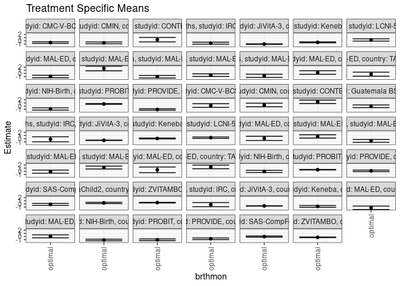

## Results Table

### Parameter: TSM

| agecat | studyid | country | intervention_level | baseline_level | estimate | ci_lower | ci_upper |
| --- | --- | --- | --- | --- | --- | --- | --- |
| Birth | IRC | INDIA | optimal | observed | -0.2140643 | -0.8642457 | 0.4361171 |
| Birth | JiVitA-3 | BANGLADESH | optimal | observed | -0.6315237 | -0.6890448 | -0.5740027 |
| Birth | Keneba | GAMBIA | optimal | observed | -0.7683700 | -1.0442296 | -0.4925103 |
| Birth | MAL-ED | BANGLADESH | optimal | observed | -1.2224665 | -1.7706905 | -0.6742425 |
| Birth | MAL-ED | PERU | optimal | observed | 0.0583340 | -0.4275227 | 0.5441906 |
| Birth | NIH-Birth | BANGLADESH | optimal | observed | -1.0904974 | -1.3410317 | -0.8399631 |
| Birth | PROBIT | BELARUS | optimal | observed | -1.0245441 | -1.2960190 | -0.7530692 |
| Birth | PROVIDE | BANGLADESH | optimal | observed | -0.7167075 | -0.9835441 | -0.4498709 |
| Birth | SAS-CompFeed | INDIA | optimal | observed | -0.0232810 | -0.2035320 | 0.1569700 |
| Birth | ZVITAMBO | ZIMBABWE | optimal | observed | -0.2585307 | -0.3539501 | -0.1631112 |
| 6 months | CMC-V-BCS-2002 | INDIA | optimal | observed | 0.1644711 | -0.4283163 | 0.7572585 |
| 6 months | CMIN | BANGLADESH | optimal | observed | 0.3370331 | -0.2363780 | 0.9104441 |
| 6 months | CONTENT | PERU | optimal | observed | 1.3420606 | 0.7958470 | 1.8882741 |
| 6 months | Guatemala BSC | GUATEMALA | optimal | observed | -0.0612368 | -0.4870431 | 0.3645695 |
| 6 months | IRC | INDIA | optimal | observed | -0.1866860 | -0.9786345 | 0.6052624 |
| 6 months | JiVitA-3 | BANGLADESH | optimal | observed | -0.5089463 | -0.5777795 | -0.4401131 |
| 6 months | Keneba | GAMBIA | optimal | observed | 0.0639224 | -0.0865383 | 0.2143831 |
| 6 months | LCNI-5 | MALAWI | optimal | observed | 0.3098994 | 0.0778004 | 0.5419984 |
| 6 months | MAL-ED | BANGLADESH | optimal | observed | 0.1107750 | -0.5483307 | 0.7698808 |
| 6 months | MAL-ED | BRAZIL | optimal | observed | 0.7270980 | 0.2077727 | 1.2464233 |
| 6 months | MAL-ED | INDIA | optimal | observed | -0.6963343 | -1.1322548 | -0.2604138 |
| 6 months | MAL-ED | NEPAL | optimal | observed | -0.1086373 | -0.5926050 | 0.3753304 |
| 6 months | MAL-ED | PERU | optimal | observed | 1.1932933 | 0.7266951 | 1.6598915 |
| 6 months | MAL-ED | SOUTH AFRICA | optimal | observed | 0.4652800 | -0.4260710 | 1.3566311 |
| 6 months | MAL-ED | TANZANIA, UNITED REPUBLIC OF | optimal | observed | 1.3647318 | 0.7886206 | 1.9408431 |
| 6 months | NIH-Birth | BANGLADESH | optimal | observed | -0.0354326 | -0.3853595 | 0.3144943 |
| 6 months | PROBIT | BELARUS | optimal | observed | 0.5049909 | 0.4293933 | 0.5805885 |
| 6 months | PROVIDE | BANGLADESH | optimal | observed | 0.1474466 | -0.0926074 | 0.3875005 |
| 6 months | SAS-CompFeed | INDIA | optimal | observed | -0.1453874 | -0.4532389 | 0.1624642 |
| 6 months | TanzaniaChild2 | TANZANIA, UNITED REPUBLIC OF | optimal | observed | 0.3132828 | 0.1179070 | 0.5086585 |
| 6 months | ZVITAMBO | ZIMBABWE | optimal | observed | 0.4059317 | 0.3121978 | 0.4996656 |
| 24 months | CMC-V-BCS-2002 | INDIA | optimal | observed | -0.5424462 | -0.7933791 | -0.2915133 |
| 24 months | CMIN | BANGLADESH | optimal | observed | -0.6364213 | -0.9203952 | -0.3524473 |
| 24 months | CONTENT | PERU | optimal | observed | 0.3677392 | -0.3430865 | 1.0785649 |
| 24 months | IRC | INDIA | optimal | observed | -0.7257510 | -1.0428669 | -0.4086351 |
| 24 months | JiVitA-3 | BANGLADESH | optimal | observed | -1.0266356 | -1.0997121 | -0.9535592 |
| 24 months | Keneba | GAMBIA | optimal | observed | -0.4735485 | -0.6160433 | -0.3310536 |
| 24 months | LCNI-5 | MALAWI | optimal | observed | 0.2697639 | -0.0818071 | 0.6213350 |
| 24 months | MAL-ED | BANGLADESH | optimal | observed | -0.9675091 | -1.3613034 | -0.5737148 |
| 24 months | MAL-ED | BRAZIL | optimal | observed | 1.5685837 | 0.8470347 | 2.2901327 |
| 24 months | MAL-ED | INDIA | optimal | observed | -1.0306078 | -1.4365128 | -0.6247028 |
| 24 months | MAL-ED | NEPAL | optimal | observed | -0.5346856 | -0.9493758 | -0.1199953 |
| 24 months | MAL-ED | PERU | optimal | observed | -0.7483736 | -1.2591993 | -0.2375479 |
| 24 months | MAL-ED | SOUTH AFRICA | optimal | observed | 0.2980867 | -0.2648226 | 0.8609960 |
| 24 months | MAL-ED | TANZANIA, UNITED REPUBLIC OF | optimal | observed | -0.2263418 | -0.8625602 | 0.4098766 |
| 24 months | NIH-Birth | BANGLADESH | optimal | observed | -0.9020656 | -1.2538905 | -0.5502407 |
| 24 months | PROBIT | BELARUS | optimal | observed | 0.6666080 | 0.5376955 | 0.7955206 |
| 24 months | PROVIDE | BANGLADESH | optimal | observed | -1.0669121 | -1.3000969 | -0.8337274 |

### Parameter: E(Y)

| agecat | studyid | country | intervention_level | baseline_level | estimate | ci_lower | ci_upper |
| --- | --- | --- | --- | --- | --- | --- | --- |
| Birth | IRC | INDIA | observed | observed | -1.0105831 | -1.1973019 | -0.8238643 |
| Birth | JiVitA-3 | BANGLADESH | observed | observed | -0.7778272 | -0.7968313 | -0.7588232 |
| Birth | Keneba | GAMBIA | observed | observed | -1.2349454 | -1.2972413 | -1.1726496 |
| Birth | MAL-ED | BANGLADESH | observed | observed | -0.9418605 | -1.0869834 | -0.7967375 |
| Birth | MAL-ED | PERU | observed | observed | -0.0520175 | -0.1725298 | 0.0684947 |
| Birth | NIH-Birth | BANGLADESH | observed | observed | -1.3499217 | -1.4444634 | -1.2553801 |
| Birth | PROBIT | BELARUS | observed | observed | -1.1491782 | -1.3593933 | -0.9389630 |
| Birth | PROVIDE | BANGLADESH | observed | observed | -1.2984586 | -1.3752758 | -1.2216415 |
| Birth | SAS-CompFeed | INDIA | observed | observed | -0.6700453 | -0.8474950 | -0.4925957 |
| Birth | ZVITAMBO | ZIMBABWE | observed | observed | -0.5154897 | -0.5413479 | -0.4896314 |
| 6 months | CMC-V-BCS-2002 | INDIA | observed | observed | -0.5026766 | -0.6536848 | -0.3516685 |
| 6 months | CMIN | BANGLADESH | observed | observed | -0.5780453 | -0.7226627 | -0.4334279 |
| 6 months | CONTENT | PERU | observed | observed | 1.0644279 | 0.9468682 | 1.1819876 |
| 6 months | Guatemala BSC | GUATEMALA | observed | observed | -0.0840134 | -0.1945572 | 0.0265305 |
| 6 months | IRC | INDIA | observed | observed | -0.5989297 | -0.7344491 | -0.4634104 |
| 6 months | JiVitA-3 | BANGLADESH | observed | observed | -0.5935161 | -0.6130518 | -0.5739805 |
| 6 months | Keneba | GAMBIA | observed | observed | -0.1846038 | -0.2354782 | -0.1337293 |
| 6 months | LCNI-5 | MALAWI | observed | observed | 0.4499404 | 0.3788501 | 0.5210308 |
| 6 months | MAL-ED | BANGLADESH | observed | observed | -0.1376763 | -0.2664642 | -0.0088885 |
| 6 months | MAL-ED | BRAZIL | observed | observed | 0.9720774 | 0.8078144 | 1.1363403 |
| 6 months | MAL-ED | INDIA | observed | observed | -0.7079979 | -0.8344175 | -0.5815783 |
| 6 months | MAL-ED | NEPAL | observed | observed | 0.1104308 | -0.0208643 | 0.2417259 |
| 6 months | MAL-ED | PERU | observed | observed | 1.0528816 | 0.9313005 | 1.1744626 |
| 6 months | MAL-ED | SOUTH AFRICA | observed | observed | 0.5421785 | 0.3900443 | 0.6943126 |
| 6 months | MAL-ED | TANZANIA, UNITED REPUBLIC OF | observed | observed | 0.5362213 | 0.4049390 | 0.6675036 |
| 6 months | NIH-Birth | BANGLADESH | observed | observed | -0.4474038 | -0.5378167 | -0.3569909 |
| 6 months | PROBIT | BELARUS | observed | observed | 0.5741099 | 0.5141290 | 0.6340908 |
| 6 months | PROVIDE | BANGLADESH | observed | observed | -0.1990907 | -0.2817968 | -0.1163845 |
| 6 months | SAS-CompFeed | INDIA | observed | observed | -0.6657084 | -0.8024377 | -0.5289791 |
| 6 months | TanzaniaChild2 | TANZANIA, UNITED REPUBLIC OF | observed | observed | 0.0809332 | 0.0282644 | 0.1336020 |
| 6 months | ZVITAMBO | ZIMBABWE | observed | observed | 0.3105514 | 0.2848767 | 0.3362262 |
| 24 months | CMC-V-BCS-2002 | INDIA | observed | observed | -0.5571505 | -0.6585247 | -0.4557763 |
| 24 months | CMIN | BANGLADESH | observed | observed | -0.8535391 | -0.9644236 | -0.7426546 |
| 24 months | CONTENT | PERU | observed | observed | 0.5902439 | 0.4560143 | 0.7244735 |
| 24 months | IRC | INDIA | observed | observed | -0.7458150 | -0.8368180 | -0.6548120 |
| 24 months | JiVitA-3 | BANGLADESH | observed | observed | -1.2978031 | -1.3210763 | -1.2745298 |
| 24 months | Keneba | GAMBIA | observed | observed | -0.8099290 | -0.8570608 | -0.7627972 |
| 24 months | LCNI-5 | MALAWI | observed | observed | -0.0477709 | -0.1296526 | 0.0341109 |
| 24 months | MAL-ED | BANGLADESH | observed | observed | -0.8192925 | -0.9412667 | -0.6973182 |
| 24 months | MAL-ED | BRAZIL | observed | observed | 0.4626233 | 0.2567495 | 0.6684971 |
| 24 months | MAL-ED | INDIA | observed | observed | -0.9516520 | -1.0670654 | -0.8362385 |
| 24 months | MAL-ED | NEPAL | observed | observed | -0.3749123 | -0.4886073 | -0.2612173 |
| 24 months | MAL-ED | PERU | observed | observed | 0.1111982 | -0.0118399 | 0.2342362 |
| 24 months | MAL-ED | SOUTH AFRICA | observed | observed | 0.4090301 | 0.2879441 | 0.5301161 |
| 24 months | MAL-ED | TANZANIA, UNITED REPUBLIC OF | observed | observed | 0.0547975 | -0.0703378 | 0.1799328 |
| 24 months | NIH-Birth | BANGLADESH | observed | observed | -0.9115790 | -1.0095022 | -0.8136559 |
| 24 months | PROBIT | BELARUS | observed | observed | 0.6981406 | 0.5843775 | 0.8119038 |
| 24 months | PROVIDE | BANGLADESH | observed | observed | -0.8928670 | -0.9755153 | -0.8102187 |

### Parameter: PAR

| agecat | studyid | country | intervention_level | baseline_level | estimate | ci_lower | ci_upper |
| --- | --- | --- | --- | --- | --- | --- | --- |
| Birth | IRC | INDIA | optimal | observed | -0.7965188 | -1.4171290 | -0.1759086 |
| Birth | JiVitA-3 | BANGLADESH | optimal | observed | -0.1463035 | -0.1995651 | -0.0930419 |
| Birth | Keneba | GAMBIA | optimal | observed | -0.4665755 | -0.7336509 | -0.1995000 |
| Birth | MAL-ED | BANGLADESH | optimal | observed | 0.2806060 | -0.2461285 | 0.8073406 |
| Birth | MAL-ED | PERU | optimal | observed | -0.1103515 | -0.5752900 | 0.3545870 |
| Birth | NIH-Birth | BANGLADESH | optimal | observed | -0.2594243 | -0.5067985 | -0.0120502 |
| Birth | PROBIT | BELARUS | optimal | observed | -0.1246341 | -0.2743169 | 0.0250488 |
| Birth | PROVIDE | BANGLADESH | optimal | observed | -0.5817511 | -0.8451472 | -0.3183550 |
| Birth | SAS-CompFeed | INDIA | optimal | observed | -0.6467643 | -0.8439062 | -0.4496224 |
| Birth | ZVITAMBO | ZIMBABWE | optimal | observed | -0.2569590 | -0.3487590 | -0.1651590 |
| 6 months | CMC-V-BCS-2002 | INDIA | optimal | observed | -0.6671477 | -1.2185343 | -0.1157612 |
| 6 months | CMIN | BANGLADESH | optimal | observed | -0.9150784 | -1.4691991 | -0.3609576 |
| 6 months | CONTENT | PERU | optimal | observed | -0.2776327 | -0.8035009 | 0.2482356 |
| 6 months | Guatemala BSC | GUATEMALA | optimal | observed | -0.0227766 | -0.4240274 | 0.3784742 |
| 6 months | IRC | INDIA | optimal | observed | -0.4122437 | -1.1767276 | 0.3522402 |
| 6 months | JiVitA-3 | BANGLADESH | optimal | observed | -0.0845698 | -0.1502584 | -0.0188813 |
| 6 months | Keneba | GAMBIA | optimal | observed | -0.2485262 | -0.3895486 | -0.1075037 |
| 6 months | LCNI-5 | MALAWI | optimal | observed | 0.1400410 | -0.0911348 | 0.3712168 |
| 6 months | MAL-ED | BANGLADESH | optimal | observed | -0.2484514 | -0.8952368 | 0.3983340 |
| 6 months | MAL-ED | BRAZIL | optimal | observed | 0.2449793 | -0.2724348 | 0.7623934 |
| 6 months | MAL-ED | INDIA | optimal | observed | -0.0116636 | -0.4292845 | 0.4059573 |
| 6 months | MAL-ED | NEPAL | optimal | observed | 0.2190681 | -0.2486048 | 0.6867410 |
| 6 months | MAL-ED | PERU | optimal | observed | -0.1404117 | -0.5856607 | 0.3048372 |
| 6 months | MAL-ED | SOUTH AFRICA | optimal | observed | 0.0768984 | -0.7857202 | 0.9395171 |
| 6 months | MAL-ED | TANZANIA, UNITED REPUBLIC OF | optimal | observed | -0.8285105 | -1.3947715 | -0.2622496 |
| 6 months | NIH-Birth | BANGLADESH | optimal | observed | -0.4119712 | -0.7490980 | -0.0748444 |
| 6 months | PROBIT | BELARUS | optimal | observed | 0.0691190 | 0.0088638 | 0.1293742 |
| 6 months | PROVIDE | BANGLADESH | optimal | observed | -0.3465372 | -0.5748076 | -0.1182668 |
| 6 months | SAS-CompFeed | INDIA | optimal | observed | -0.5203210 | -0.7095357 | -0.3311064 |
| 6 months | TanzaniaChild2 | TANZANIA, UNITED REPUBLIC OF | optimal | observed | -0.2323496 | -0.4203044 | -0.0443948 |
| 6 months | ZVITAMBO | ZIMBABWE | optimal | observed | -0.0953802 | -0.1842535 | -0.0065070 |
| 24 months | CMC-V-BCS-2002 | INDIA | optimal | observed | -0.0147043 | -0.2640699 | 0.2346613 |
| 24 months | CMIN | BANGLADESH | optimal | observed | -0.2171178 | -0.5083993 | 0.0741637 |
| 24 months | CONTENT | PERU | optimal | observed | 0.2225047 | -0.4586346 | 0.9036440 |
| 24 months | IRC | INDIA | optimal | observed | -0.0200640 | -0.3254961 | 0.2853682 |
| 24 months | JiVitA-3 | BANGLADESH | optimal | observed | -0.2711675 | -0.3418420 | -0.2004929 |
| 24 months | Keneba | GAMBIA | optimal | observed | -0.3363805 | -0.4728434 | -0.1999176 |
| 24 months | LCNI-5 | MALAWI | optimal | observed | -0.3175348 | -0.6618223 | 0.0267526 |
| 24 months | MAL-ED | BANGLADESH | optimal | observed | 0.1482166 | -0.2342991 | 0.5307323 |
| 24 months | MAL-ED | BRAZIL | optimal | observed | -1.1059604 | -1.8173205 | -0.3946004 |
| 24 months | MAL-ED | INDIA | optimal | observed | 0.0789558 | -0.3142088 | 0.4721204 |
| 24 months | MAL-ED | NEPAL | optimal | observed | 0.1597733 | -0.2430675 | 0.5626141 |
| 24 months | MAL-ED | PERU | optimal | observed | 0.8595718 | 0.3687650 | 1.3503786 |
| 24 months | MAL-ED | SOUTH AFRICA | optimal | observed | 0.1109434 | -0.4292581 | 0.6511449 |
| 24 months | MAL-ED | TANZANIA, UNITED REPUBLIC OF | optimal | observed | 0.2811393 | -0.3236227 | 0.8859014 |
| 24 months | NIH-Birth | BANGLADESH | optimal | observed | -0.0095135 | -0.3485951 | 0.3295681 |
| 24 months | PROBIT | BELARUS | optimal | observed | 0.0315326 | -0.0929932 | 0.1560584 |
| 24 months | PROVIDE | BANGLADESH | optimal | observed | 0.1740451 | -0.0522285 | 0.4003188 |